# ME323 - Introdução aos Modelos Probabilísticos

## Intervalo de confiança para a média populacional

## Revisão

- Vimos que podemos usar uma estatística para estimar um parâmetro de uma distribuição que temos interesse.
- Por ex: podemos usar a proporção amostral (\(\hat{p}\)), obtida a partir de um amostra aleatória, se estamos interessados na proporção populacional (\(p\)).
- Por ex: podemos usar a média amostral (\(\bar{x}\)), obtida a partir de um amostra aleatória, se estamos interessados na média populacional (\(\mu\)).
- **Resultado:** Se \(X\) tem \(\mathbb E(X)=\mu\) e \(Var(X)=\sigma^2\), então a distribuição da média amostral, \(\bar{X}_n\), tem \[\mathbb E(\bar{X}_n)=\mu \quad \mbox{e} \quad Var(\bar{X}_n)=\frac{\sigma^2}{n}\]

## Distribuição da Média Amostral

A média amostral, \(\bar{X}_n\), tem em geral valores diferentes para diferentes amostras aleatórias obtidas: é uma variável aleatória.

> Para obtermos a distribuição da média amostral:
- Coletar uma a.a. de tamanho \(n\) a partir da população com distribuição \(X\) e guardar o valor da média desta amostra.
- Coletar outra a.a. de tamanho \(n\) a partir da população com distribuição \(X\) e guardo o valor da média desta amostra. Repetir isso várias vezes.
- Construir um histograma com todas as médias obtidas para estudar o comportamento de \(\bar{X}_n\): avaliando a média, a dispersão e a distribuição.

## Teorema Central do Limite

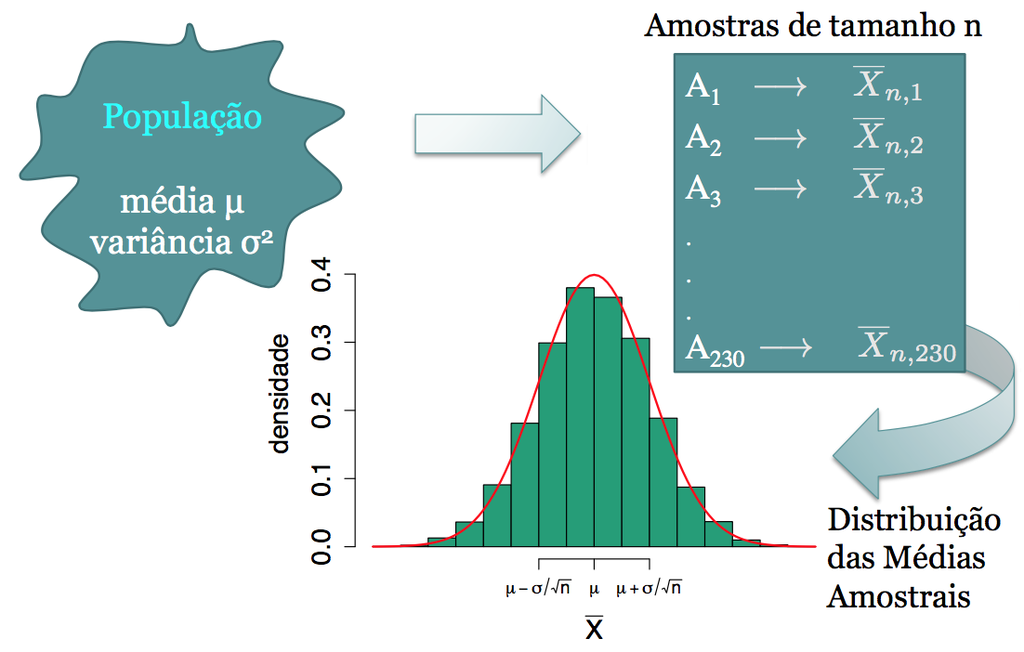

## Teorema Central do Limite

Na prática: iremos coletar somente **uma amostra** de tamanho \(n\), não faremos inúmeras vezes esse processo. Teremos apenas um valor: \(\bar{x}\).

> Então como saberemos as propriedades deste estimador? Quão útil ele é?

> **Resultado (TCL):**

Para amostras aleatórias simples \(X_{1},...,X_{n}\) coletadas de uma população com média \(\mu\) e variância \(\sigma^{2}\), a distribuição amostral de \(\bar{X}_{n}\) aproxima-se de uma distribuição Normal de média \(\mu\) e variância \(\frac{\sigma^{2}}{n}\), quando \(n\) for suficientemente grande, isto é, \[ \bar{X}_{n} \sim N\left(\mu, \frac{\sigma^{2}}{n} \right)\]

## Teorema Central do Limite

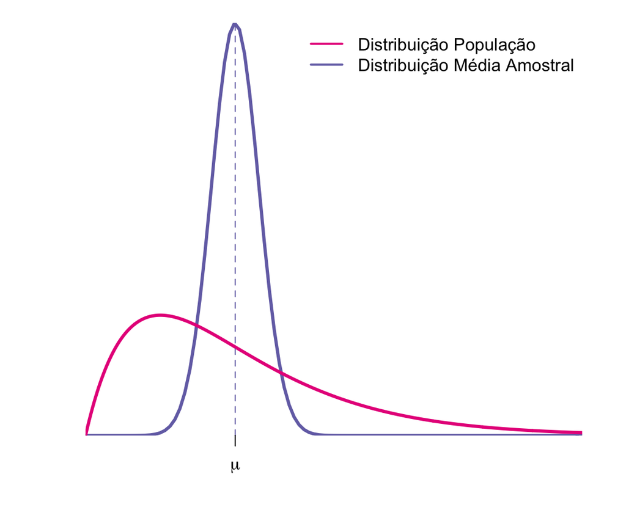

## Usando o TCL para construir um IC

- Temos uma amostra aleatoria \(X_1,\ldots,X_n\) e estamos usando a média amostral \(\bar{X}_n\) para estimar \(\mu\), a média populacional.
- Quão boa é esta estimativa? Ela tem boa precisão? Qual o grau de confiança?
- Em geral: queremos alto grau de confiança, por exemplo, \(1-\alpha=0.95\).
- Imagine que seja possível coletar uma amostra de tamanho \(n\) da população várias vezes. Para cada vez, você calcula \(\bar{x}\) é constrói um IC de 95% para \(\mu\). Imagine também que você conhece \(\mu\) e conte quantos dos intervalos contêm \(\mu\). A proporção de intervalos que contem \(\mu\) será próxima a 0.95.

## Interpretação do Intervalo de Confiança para \(\mu\)

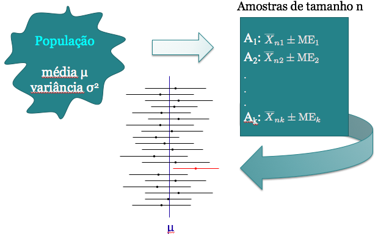

## Exemplo

Uma variável aleatória \(X\) tem distribução normal, com média 100 e desvio padrão 10.

- Qual a \(P(90 < X < 110)\)?
- Se \(\bar{X}\) for a média de uma amostra de 16 elementos retirados dessa população, calcule \(P(90 < \bar{X} < 110)\).
- Represente, num único gráfico, as distribuições de \(X\) e \(\bar{X}\).
- Que tamanho deveria ter a amostra para que \(P(90 < \bar{X} < 110) = 0.95\)?

*Fonte: Morettin & Bussab*, Estatística Básica \(5^a\) edição, pág 274.

## Exemplo

Qual a \(P(90 < X < 110)\)?

> Devemos padronizar o evento, para usar a distribuição normal padrão.

> \[P(90 < X < 110) = P\left( \frac{90-100}{10} < \frac{X-100}{10} < \frac{110-100}{10} \right) \]

\[= P(-1 < Z < 1) = P(Z<1) - P(Z<-1) = \Phi(1) - \Phi(-1)\]

## Exemplo

Calcule \(P(90 < \bar{X} < 110)\), sendo \(\bar{X}\) for a média de uma amostra de 16 elementos dessa população

> Sabemos que \(\mathbb E(\bar{X})=100\) e \(Var(\bar{X}) = \sigma^2/n=100/16\).

> Consequentemente, o desvio padrão de \(\bar{X}\) será \(\sigma/ \sqrt{n}=10/4\).

> Temos então que \[\begin{aligned} P(90 < \bar{X} < 110) &= P\left( \frac{90-100}{10/4} < \frac{\bar{X}-100}{10/4} < \frac{110-100}{10/4} \right) \\ & = P ( -4 < Z < 4) \\ &= P(Z<4) - P(Z<-4) \\ &= \Phi(4) - \Phi(-4) \end{aligned}\]

> Se consultarmos a tabela agora, veremos que a probabilidade \(P(Z<4)\) é tão grande nem está listada. Ela então pode ser considerada como aproximadamente igual a 1. De fato, com a ajuda de algum método de integração numérica, podemos verificar que \(\Phi(4) - \Phi(-4)\) é igual a \(0.9999367\).

## Exemplo

Distribuições de \(X\) e \(\bar{X}\):

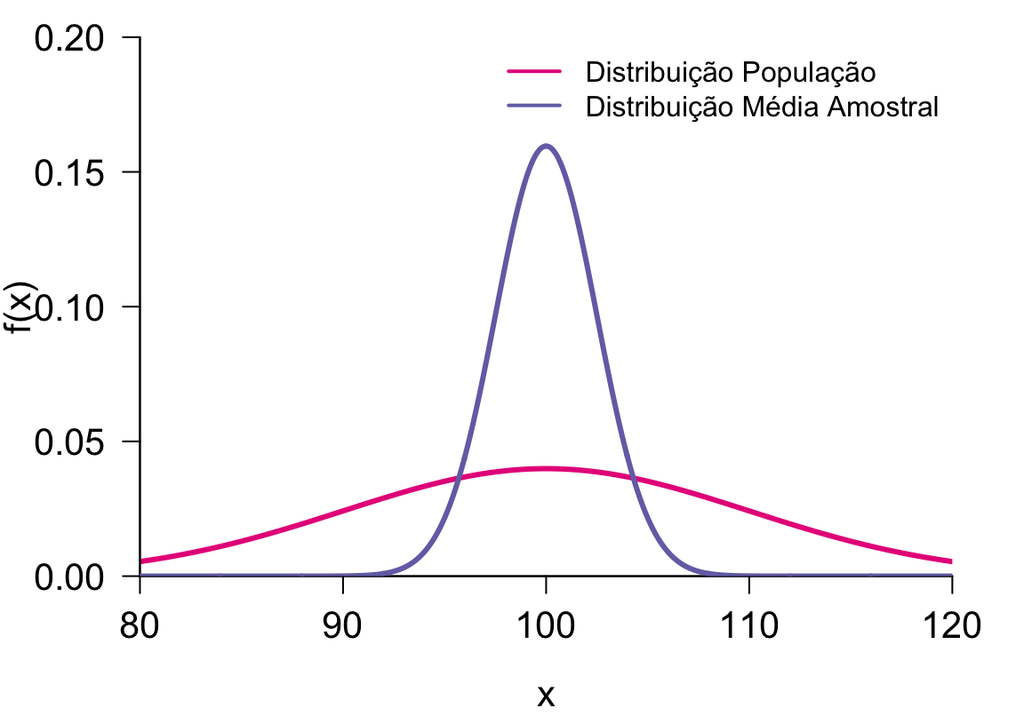

## Exemplo

Que tamanho deveria ter a amostra para que \(P(90 < \bar{X} < 110) = 0.95\)?

> Queremos resolver a seguinte equação:

\[P\left( \frac{90-100}{10/\sqrt{n}} < \frac{\bar{X}-100}{10/\sqrt{n}} < \frac{110-100}{10/\sqrt{n}} \right) = 0.95\]

> Consultando a tabela, vemos que \(P(-z_{0.025}<Z<z_{0.025})=0.95\) se \(z_{0.025} = 1.96\).  
> Então a equação que queremos resolver pode ser reescrita como:

\[ \frac{110-100}{10/\sqrt{n}} = 1.96 \quad \Leftrightarrow \quad \sqrt{n}\frac{110-100}{10} = 1.96 \quad \Leftrightarrow \quad n = 1.96^2\]

> Portanto, \(n=4\) é suficiente para obtermos a confiança desejada.

## Intervalo de Confiança para \(\mu\)

- Coletamos uma amostra aleatória \(X_1,X_2,\ldots,X_n\) de uma população com média \(\mu\) e a variância \(\sigma^2\) e usamos \(\bar{X}_n\) para estimar \(\mu\).
- Pelo TCL: \[\bar{X}_n \sim N(\mu,\sigma^2/n)\]
- Propriedade da Normal: \[Z=\frac{\bar{X}_n-\mu}{\sqrt{\sigma^2/n}} \sim N(0,1)\]

\[P(-z_{\alpha/2}<Z<z_{\alpha/2})=1-\alpha\]

## Como encontrar \(z_{\alpha/2}\)

\[P(|Z|\leq z_{\alpha/2})=P(-z_{\alpha/2}\leq Z \leq z_{\alpha/2})=1-\alpha\]

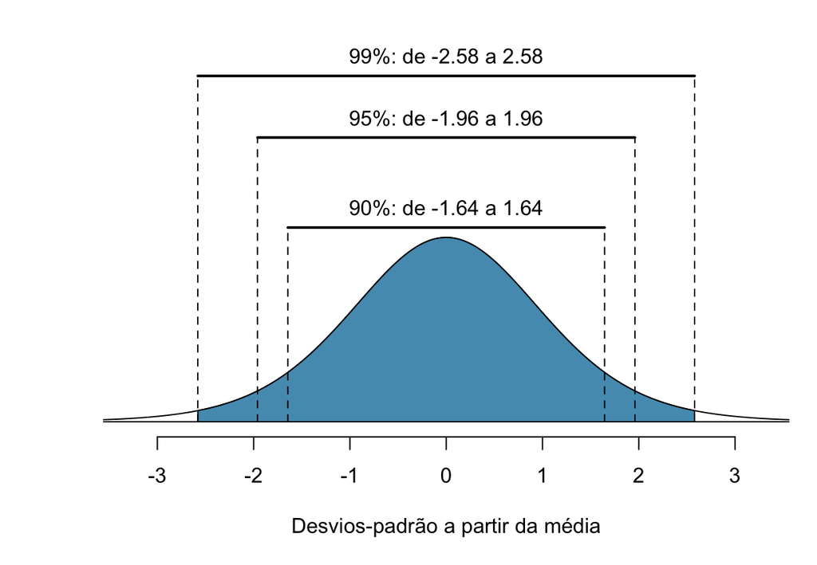

## Como encontrar \(z_{\alpha/2}\)

\[P(|Z|\leq z_{\alpha/2})=P(-z_{\alpha/2}\leq Z \leq z_{\alpha/2})=1-\alpha\]

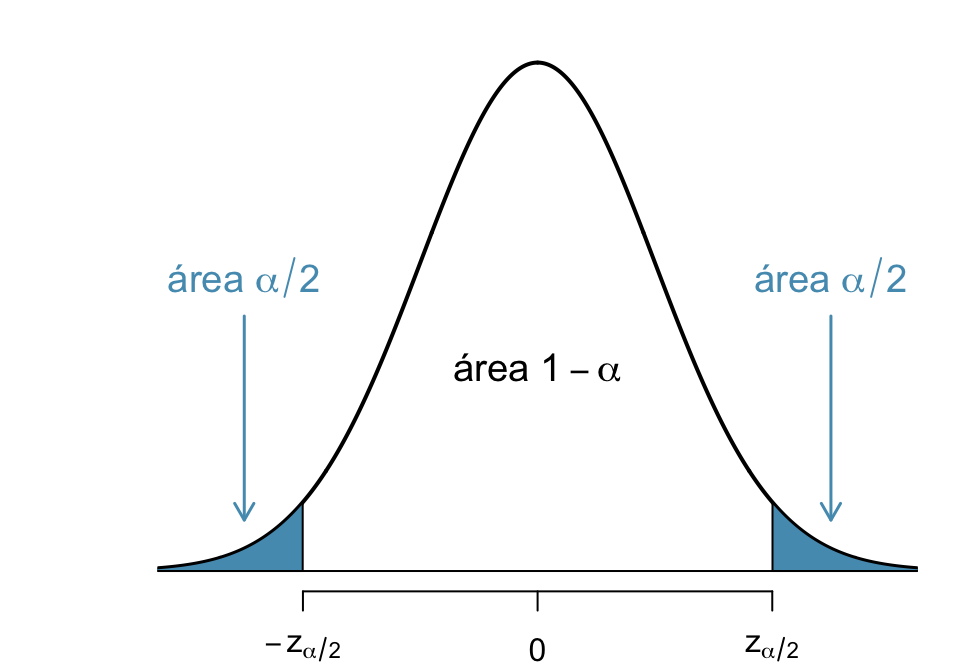

Procure na tabela o valor de \(z\) tal que a probabilidade acumulada até o valor de \(z\), isto é \(P(Z\leq z)=\Phi(z)\), seja \(1-\alpha/2\).

## Exemplo

Encontrar \(z_{0.05}\) tal que \(0.90 = P\left(-z_{0.05}\leq Z\leq z_{0.05}\right)\).

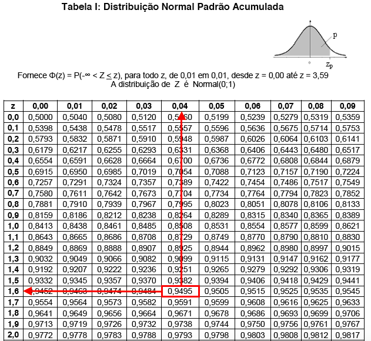

Pela tabela, \(z_{0.05} = 1.64.\)

## Intervalo de Confiança para \(\mu\): \(\sigma\) conhecido

Seja \(X_1,\ldots, X_n\) uma a.a. de uma população com média \(\mu\) e variância \(\sigma^2\) conhecida. Então,

\[Z=\frac{\bar{X}_n-\mu}{\sqrt{\sigma^2/n}} \sim N(0,1)\]

\[P(-z_{\alpha/2}<Z<z_{\alpha/2})=1-\alpha\]

Um Intervalo de \(100(1-\alpha)\%\) de confiança para \(\mu\) é dado por: \[IC(\mu, 1-\alpha) = \left[ \bar{x} - z_{\alpha/2} \frac{\sigma}{\sqrt{n}}\,;\,\bar{x} +z_{\alpha/2}\frac{\sigma}{\sqrt{n}}\right]\]

## Exemplo: Café

Uma máquina enche pacotes de café com variância igual a 100\(g^2\). Ela estava regulada para encher os pacotes com uma média de 500g. Mas o fabricante desconfia que a máquina está desregulada e quer então estimar a nova média \(\mu\).

Uma amostra de 25 pacotes apresentou uma média de 485g. Encontre um \(IC\) de \(95\%\) para a verdadeira média \(\mu\).

\(\bar x = 485, n=25, \sigma=10, \alpha=0.05, z_{0.025}=1.96\)

\[ \begin{aligned} IC(\mu, 0.95) &= \left[ \bar{x} - z_{0.025} \frac{\sigma}{\sqrt{n}};\,\bar{x} +z_{0.025}\frac{\sigma}{\sqrt{n}}\right] \\ &= \left[485 - 1.96 \frac{10}{5}; 485 + 1.96 \frac{10}{5} \right] \\ &= [485 - 3.92; 485 + 3.92] \\ &= [481.08; 488.92] \end{aligned} \]

## Tamanho da Amostra

**Exemplo:** Por experiência, sabe-se que o peso de um salmão de certo criatório segue uma distribuição normal com uma média que varia a cada estação, mas com desvio-padrão sempre igual a 0.3 libras.

> Se quisermos estimar o peso médio dos peixes de maneira que nossa estimativa seja diferente da verdadeira média em no máximo 0.1 libras para mais ou para menos com probabilidade igual a 0.9, qual o tamanho amostral necessário?

**Solução** \[IC(\mu, 1-\alpha) = \left[ \bar{x} -z_{\alpha/2}\frac{\sigma}{\sqrt{n}}\,;\, \bar{x} +z_{\alpha/2}\frac{\sigma}{\sqrt{n}}\right]\]

Margem de erro: \(z_{\alpha/2}\frac{\sigma}{\sqrt{n}}\)

## Tamanho da Amostra

Margem de erro 0.1, isto é, \[z_{\alpha/2}\frac{\sigma}{\sqrt{n}}=0.1\]

\(\alpha=0.1\) (90% de confiança) e \(z_{0.05}=1.645\).

\[1.645\frac{0.3}{\sqrt{n}}=0.1 \quad \Rightarrow \quad n=24.35\]

Tamanho amostral: 25

Em geral, para uma margem de erro \(m\) e confiança \(100(1-\alpha)\%\):

\[n=\left( \frac{z_{\alpha/2}}{m}\right)^2\sigma^2\]

## Intervalo de Confiança para \(\mu\): \(\sigma\) desconhecido

Seja \(X_1, \ldots, X_n\) uma a.a. de uma população com média \(\mu\), mas com variância \(\sigma^2\) desconhecida

Nesse caso, usaremos a variância amostral (\(s^2\)) como uma estimativa de \(\sigma^2\): \[s^2=\frac{1}{n-1}\sum_{i=1}^n(x_i-\bar{x})^2\]

> Como consequência, não temos mais distribuição Normal, mas sim a **distribuição \(t\)-student** com \(n-1\) graus de liberdade:

\[T=\frac{\bar{X}_n-\mu}{\sqrt{s^2/n}}\sim t_{n-1}\]

\[P(-t_{n-1,\alpha/2}<T<t_{n-1,\alpha/2})=1-\alpha\]

Um intervalo de \(100(1-\alpha)\%\) de confiança para \(\mu\) é dado por: \[IC(\mu, 1-\alpha) = \left[ \bar{x} -t_{n-1,\alpha/2}\frac{s}{\sqrt{n}};\, \bar{x} +t_{n-1,\alpha/2}\frac{s}{\sqrt{n}}\right]\]

## Como encontrar \(t_{n-1,\alpha/2}\)

\[P(-t_{n-1,\alpha/2} < T < t_{n-1,\alpha/2}) = 1-\alpha\]

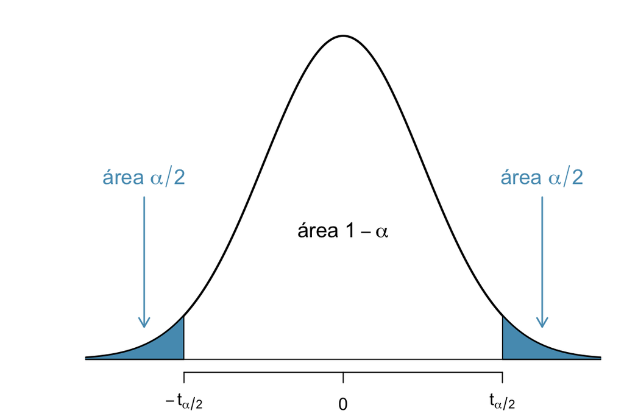

Os valores da distribuição \(t\)-student também encontram-se tabelados.

## Distribuição \(t\)-student e Normal Padrão

Para \(n\) grande a distribuição \(t\)-student se aproxima da normal padrão \(N(0,1)\).

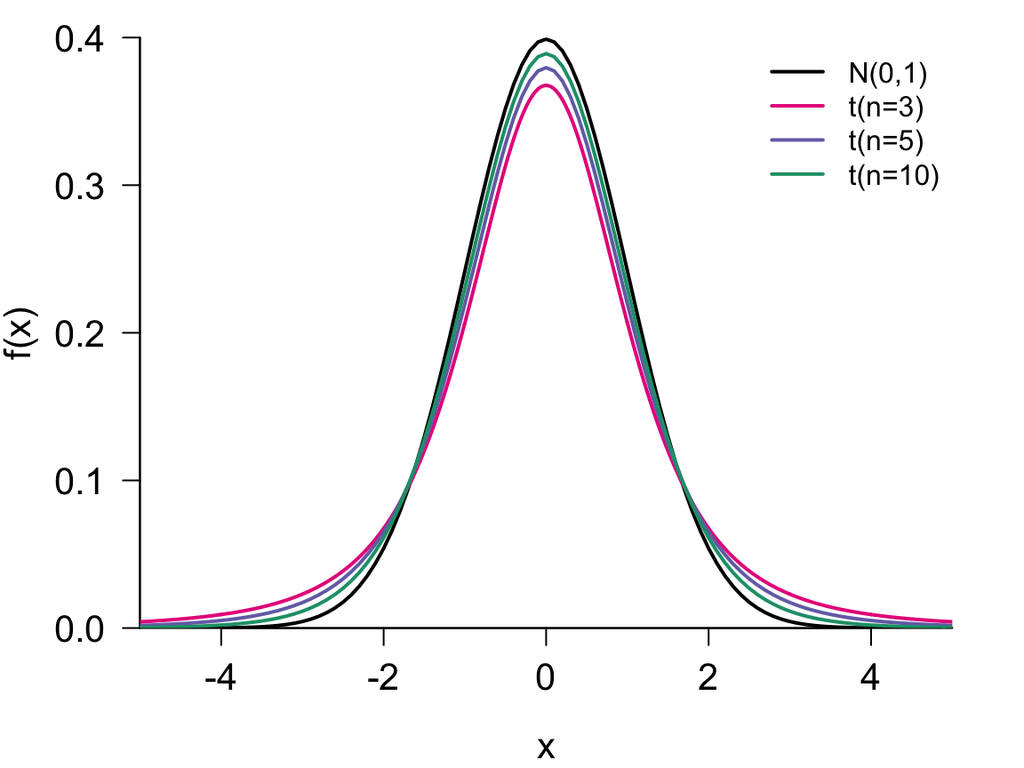

## Exemplo: Café

No exemplo da máquina que enche pacotes de café, suponha agora que a variância é **desconhecida**.

Lembre-se que uma amostra de \(25\) pacotes apresentou uma média de 485g. Observou-se um desvio padrão na amostra de 7.1g

Encontre um IC de 95% para a verdadeira média \(\mu\)

\[ \begin{aligned} IC(\mu, 0.95) &= \left[ \bar{x} - t_{24, 0.025} \frac{s}{\sqrt{n}};\,\bar{x} +t_{24, 0.025}\frac{s}{\sqrt{n}}\right] \\ &= \left [485 - 2.06 \frac{7.1}{5}; 485 + 2.06 \frac{7.1}{5} \right] \\ &= [485 - 2.93; 485 + 2.93] \\ &=[482.07; 487.93] \end{aligned} \]

## Exemplo: Quantas horas de TV por dia?

O histograma a seguir apresenta a distribuição do número de horas de TV assistidas por dia entre os participantes de um estudo em que se coletou uma amostra aleatória.

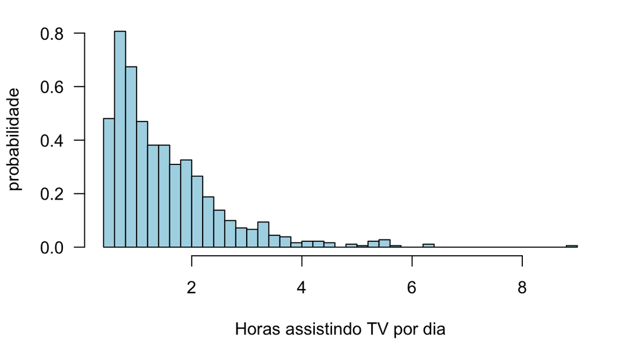

## Exemplo: horas de TV por dia

Encontre um IC de \(95\%\) para a média de horas que uma pessoa assiste por dia.

- \(n=905\) pessoas responderam.
- \(x_i\) é o número de horas de TV que a pessoa \(i\) da amostra assiste.
- \(\bar{x}=1.52\) e \(s=1\)
- Erro padrão da média amostral: \(s/\sqrt{n}=0.03\)

## Exemplo: horas de TV por dia

> Utilizamos a distribuição Normal e não a distribuição t, pois \(n\) é grande.
- Pelo TCL: \(\bar{X}_n \sim N(\mu,\sigma^2/n)\)
- O IC de 95% para \(\mu\) é dado por:

> \[\begin{aligned} IC(\mu, 0.95) &= \left[\bar{x}-1.96 \frac{s}{\sqrt{n}};\,\bar{x}+1.96\frac{s}{\sqrt{n}} \right] \\ &= [1.52 - 0.06; 1.52 + 0.06] \\ &= [1.46\,;\,1.58] \end{aligned}\]

> Com grau de confiança igual a 95%, estimamos que a média populacional de horas de TV está entre 1.46 e 1.58 horas.

## Exemplo - Leite materno

O Ministério da Saúde está preocupado com quantidade de um certo componente tóxico no leite materno.

> Em uma amostra de 20 mulheres, a quantidade do componente para cada uma foi:

```
## 16 0 0 2 3 6 8 2 5 0 12 10 5 7 2 3 8 17 9 1
```

Obtenha um intervalo de confiança de 95% para a quantidade média do componente no leite materno.

## Exemplo - Leite Materno

Média e desvio-padrão da amostra (\(n=20\)): \(\bar{x}=5.8\) e \(s=5.08\).

Pela distribuição t, para \(\alpha= 0.05\): \(t_{19,0.025}= 2.093\)

Portanto, o IC de 95% é dado por: \[IC(\mu, 0.95) = \left[ \bar{x} -t_{n-1,\alpha/2}\frac{s}{\sqrt{n}}\,;\, \bar{x} +t_{n-1,\alpha/2}\frac{s}{\sqrt{n}}\right]\]

\[\begin{aligned} &= [5.8 - 2.39; 5.8 + 2.39] \\ &= [3.41\,;\,8.19] \end{aligned}\]

Com grau de confiança igual a 95%, estimamos que a média da quantidade do componente entre as mulheres está entre 3.41 e 8.19.

## Exemplo - Exame

O desvio-padrão da pontuação em um certo exame é 11.3. Uma amostra aleatória de 81 estudantes que fizeram o exame foi coletada e a nota de cada estudantes foi anotada. A pontuação média entre os estudantes amostrados foi 74.6.

Encontre um intervalo de 90% de confiança para a pontuação média entre todos os estudantes que fizeram o exame.

> \(\bar{x}=74.6\), \(\sigma=11.3\), \(n=81\), \(\alpha=0.10\) e \(z_{0.05}=1.645\)

> \[ \begin{aligned} IC(\mu, 0.90) &= \left[ 74.6 - 1.645 \frac{11.3}{9};\, 74.6 + 1.645\frac{11.3}{9}\right] \\ &= [74.6 - 2.07;\, 74.6 + 2.07] = [72.53;\, 76.67] \end{aligned} \]

> Com grau de confiança igual a 90%, estimamos que a pontuação média entre os estudantes está entre 72.53 e 76.67.

## Exemplo: precisão e tamanho amostral

Qual deve ser o tamanho de uma amostra cuja população da qual ela será sorteada possui um desvio-padrão igual a 10, para que a diferença da média amostral para a média da população, em valor absoluto, seja menor que 1, com coeficiente de confiança igual a:

- \(95\%\)
- \(99\%\)

*Fonte: Morettin & Bussab*, Estatística Básica \(5^a\) edição, pág 308.

## Exemplo: precisão e tamanho amostral

Pelo TCL: \(\bar{X}_n \sim N(\mu, 10^2/n)\)

> Queremos \(P(|\bar{X}-\mu|<1) = 0.95\)

> \[P(-1<\bar{X}-\mu<1) = 0.95\]

> \[P\left(-\frac{1}{10/\sqrt{n}}<\frac{\bar{X}-\mu}{10/\sqrt{n}}<\frac{1}{10/\sqrt{n}}\right) = 0.95\]

> O que é equivalente a \[P \left( -\sqrt{n}/10 < Z < \sqrt{n}/10 \right)=0.95\]

> Como \(P(-1.96 < Z < 1.96) = 0.95\), então \[\frac{\sqrt{n}}{10} = 1.96 \quad \Rightarrow \quad n \approx 385\]

## Exemplo: precisão e tamanho amostral

De modo análogo, para um grau de confiança de \(99\%\), temos que \[P(-2.58 < Z < 2.58) = 0.99\]

Então, \[\sqrt{n}/10 = 2.58 \quad \Rightarrow \quad n \approx 665\]

Em geral, como já dissemos anteriormente, para uma margem de erro \(m\): \[n=\left(\frac{z_{\alpha/2}}{m}\right)^2 \sigma^2\]

## Leituras

[figure not shown]

- Devore: capítulo 7.
- [Ross](http://www.sciencedirect.com/science/article/pii/B9780123743886000089): capítulo 8.
- [OpenIntro](https://www.openintro.org/stat/textbook.php): seção 4.2.
- Magalhães: capítulo 7.

Slides produzidos pelos professores:

- Samara Kiihl
- Tatiana Benaglia
- Benilton Carvalho